## Lab04b

# Read images from files and display the images

This notebook covers three different ways of reading images from a file.  
You will need to do this when you want to compare an image to some of the images files  
which contain categories e.g., (CIFAR-10, CIFAR-100 and other data sets:  
https://www.tensorflow.org/datasets/catalog/overview) for image classification (CNN) models.

**Python Modules:**  
**1. OpenCV**  
**2. Pillow**  
**3. MatplotLib**

There are also other ways:  
Python's scikit (load_sample_image)  
Tensorflow:  
from tensorflow.keras import datasets, layers, models  
(train_images, train_labels), (test_images, test_labels) = datasets.cifar10.load_data()  
tfds.core.DatasetBuilder

**Excellent article on OpenCV vs Pillow**  
https://www.reddit.com/r/Python/comments/4u7qlu/pillow_vs_opencv/

https://matplotlib.org/tutorials/introductory/images.html  
https://www.geeksforgeeks.org/reading-images-in-python/  
https://towardsdatascience.com/cifar-10-image-classification-in-tensorflow-5b501f7dc77c

## **Method 1: Use Opencv-python**

OpenCV (Open Source Computer Vision Library: http://opencv.org) is an open-source BSD-licensed library that includes  
several hundreds of computer vision algorithms.  
It allows you to modify pixels in place.

OpenCV Functionality includes:  
Image/video I/O, processing, display (core, imgproc, highgui)  
Object/feature detection (objdetect, features2d, nonfree)  
Geometry-based monocular or stereo computer vision (calib3d, stitching, videostab)  
Computational photography (photo, video, superres)  
Machine learning & clustering (ml, flann)  
CUDA acceleration (gpu)  
https://www.geeksforgeeks.org/opencv-overview/

```python
#https://pypi.org/project/opencv-python/
!pip install opencv-python
```

```python
!pip show opencv-python
```

```
Name: opencv-python
Version: 4.8.1.78
Summary: Wrapper package for OpenCV python bindings.
Home-page: https://github.com/opencv/opencv-python
Author:
Author-email:
License: Apache 2.0
Location: /Users/shiveshrajsahu/anaconda3/lib/python3.10/site-packages
Requires: numpy, numpy, numpy, numpy, numpy
Required-by:
```

**Set up Imports**

```python
import cv2
```

```python
#This code displays an image in a pop up window
# Read RGB image
import sys

img = cv2.imread('grumpycat1.jpg')

# Display img with window name
myimg = cv2.imshow('Grumpy Cat Photo', img)

# Maintain output window until user presses a key
cv2.waitKey(0)

# Destroy window on screen
cv2.destroyAllWindows()
```

```python
#This code displays an image in a pop up window
# Read RGB image
import sys

cv2.namedWindow("output",cv2.WINDOW_NORMAL)
img = cv2.imread('grumpycat1.jpg')
imgResized = cv2.resize(img, (600,500))

# Display img with window name
myimg = cv2.imshow('Grumpy Cat Photo', imgResized)

# Maintain output window until user presses a key
cv2.waitKey(0)

# Destroy window on screen
cv2.destroyAllWindows()
```

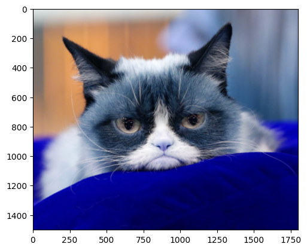

```python
#This example displays the images using matplot lib
import numpy as np
from matplotlib import pyplot as plt

img = cv2.imread('grumpycat1.jpg')
#img = cv2.imread('grumpycat1.jpg',0)   #Displays in black and white
# Below uses matplotlib
plt.imshow(img, interpolation = 'bicubic')
#plt.xticks([]), plt.yticks([])  # to hide tick values on X and Y axis
plt.show()
```

Why are colors different? OpenCV uses BGR as its default colour order for images, matplotlib uses RGB. When you display an image loaded with OpenCv in matplotlib the channels will be back to front.

The easiest way of fixing this is to use OpenCV to explicitly convert it back to RGB.

[figure not shown]

```python
img = cv2.imread('grumpycat1.jpg')
#RGB_img = cv2.cvtColor(img,cv2.COLOR_BGR2RGB)
# The following will create a gray image
GRAY_img = cv2.cvtColor(img, cv2.COLOR_BGR2GRAY)

# Display image using matplotlib
#plt.imshow(RGB_img, interpolation = 'bicubic')
plt.imshow(GRAY_img, interpolation = 'bicubic')
plt.xticks([]), plt.yticks([])  # to hide tick values on X and Y axis
plt.show()
```

## Obtain size of an image using OpenCV

Obtain dimensions of image using .shape

`Height` represents the number of pixel rows in the image or the number of pixels in each column of the image array.

`Width` represents the number of pixel columns in the image or the number of pixels in each row of the image array.

`Number of Channels` represents the number of components used to represent each pixel.

```python
dimensions = img.shape
height = img.shape[0]   # Height is at index 0
width = img.shape[1]    # Width is at index 1
channels = img.shape[2] # no. of channels is at index 2

print('Image Dimension    : ',dimensions)
print('Image Width        : ',width)
print('Image Height       : ',height)
print('Number of Channels : ',channels)
```

```
Image Dimension    :  (1501, 1801, 3)
Image Width        :  1801
Image Height       :  1501
Number of Channels :  3
```

```python
#Here's the filesize of grumpcat picture
!dir grumpycat1.jpg
```

```
/bin/bash: dir: command not found
```

**How to resize an Image using OpenCV**

```python
img_size = 300
# resizing an image for ConvNet processing
resized_img = cv2.resize(img,(img_size,img_size))

# Display img with window name
myimg = cv2.imshow('Grumpy Cat Resized', resized_img)

# Maintain output window until
# user presses a key
cv2.waitKey(0)

# Destroying present windows on screen
cv2.destroyAllWindows()

dimensions = resized_img.shape
height = resized_img.shape[0]   # Height is at index 0
width = resized_img.shape[1]    # Width is at index 1
channels = resized_img.shape[2] # no. of channels is at index 2
print('Image Dimension    : ',dimensions)
print('Image Width        : ',width)
print('Image Height       : ',height)
print('Number of Channels : ',channels)
```

```
Image Dimension    :  (300, 300, 3)
Image Width        :  300
Image Height       :  300
Number of Channels :  3
```

#### Save image transformed in OpenCV

```python
cv2.imwrite('..\lab04_Muthu\smaller_cat.jpg',resized_img)
```

```
True
```

## Method 2: Use Pillow

Use Image.open  
Note: Opens and identifies the given image file.

**This is a lazy operation; this function identifies the file, but the file remains open and the actual image data is NOT read from the file until you try to process the data (or call the load() method). See new().**

Use of %matplotlib inline  
Tells IPython where (and how) to display plots  
With this backend, the output of plotting commands is displayed inline within frontends like the Jupyter notebook, directly below the code cell that produced it. The resulting plots will then also be stored in the notebook document.

```python
 %matplotlib inline
```

```python
!pip install Pillow
```

```python
!pip show Pillow
```

```
Name: Pillow
Version: 9.4.0
Summary: Python Imaging Library (Fork)
Home-page: https://python-pillow.org
Author: Alex Clark (PIL Fork Author)
Author-email: aclark@python-pillow.org
License: HPND
Location: /Users/shiveshrajsahu/anaconda3/lib/python3.10/site-packages
Requires:
Required-by: matplotlib
```

**Set up Imports**

```python
from PIL import Image
```

```python
#Displays image in a pop-up window
img1 = Image.open("grumpycat1.jpg")
#img1.show()
img1.rotate(45).show() #Rotates image by 45 degrees
```

```python
#Displays size of file (width x height) and Mode of file
print("Format: {0}\nSize: {1}\nMode: {2}".format(img1.format,
    img1.size, img1.mode))
```

```
Format: JPEG
Size: (1801, 1501)
Mode: RGB
```

## Save image in a different format

```python
img1.save('nicekitty.png', 'png')
img2 = Image.open("nicekitty.png")
img2.show()
```

```python
!dir *.png
```

```
/bin/bash: dir: command not found
```

**Convert image to grayscale**  
Use image.covert()  
When translating a color image to greyscale (mode “L”), the library uses the ITU-R 601-2 luma transform:  
L = R *299/1000 + G* 587/1000 + B * 114/1000  
The default method of converting a greyscale (“L”) or “RGB” image into a bilevel (mode “1”) image uses Floyd-Steinberg dither to approximate the original image luminosity levels. If dither is NONE, all values larger than 128 are set to 255 (white), all other values to 0 (black).  
https://pillow.readthedocs.io/en/stable/reference/Image.html

```python
g_img = img1.convert('L')
g_img.show()
```

**How to resize an Image using PIL**  
Use image.resize  
Image.resize resizes to the dimensions you specify.

```python
img1 = Image.open("grumpycat1.jpg")
newresized_img = img1.resize((200,200), Image.LANCZOS)   #ANTIALIAS is removed
quality_val = 90  #You can vary it considering the tradeoff for quality vs performance
newresized_img.save("sizedgrumpycat.jpg", "JPEG", quality=quality_val)

#Displays size of file (width x height) and Mode of file
print("Format: {0}\nSize: {1}\nMode: {2}".format(newresized_img.format,
    newresized_img.size, newresized_img.mode))
```

```
Format: None
Size: (200, 200)
Mode: RGB
```

```python
#Displays new resized image in a pop-up window
new_img = Image.open("sizedgrumpycat.jpg")
new_img.show()
```

```python
!dir resizedgrumpycat.jpg
```

```
/bin/bash: dir: command not found
```

**Create a thumbnail from the original file**  
Use image.thumbnail  
Create a thumbnail from the original file (grumpycat1.jpg). Note: Function modifies the Image object in place. Image.thumbnail resizes to the largest size that (a) preserves the aspect ratio, (b) does not exceed the original image, and (c) does not exceed the size specified in the arguments of thumbnail. Also image.thumbnail preserves the aspect ratio. https://stackoverflow.com/questions/29367990/what-is-the-difference-between-image-resize-and-image-thumbnail-in-pillow-python

```python
max_size = (100, 100) #defines size of thumbnail
#Displays size of file of thumnail file
#Provides size of file (width x height) and Mode of file
print("Format: {0}\nSize: {1}\nMode: {2}".format(new_img.format,
    new_img.size, new_img.mode))
# Recall img1 opens grumpcat1.jpg--> img1 = Image.open("grumpycat1.jpg")
# Create thumbnail
img1.thumbnail(max_size)
img1.save('grumpycat_thumb.png')
img1.show()
#imgplot = plt.imshow(img1)
```

```
Format: JPEG
Size: (200, 200)
Mode: RGB
```

```python
!dir grumpycat_thumb.png
```

```
/bin/bash: dir: command not found
```

## **Method 3: Use Matplotlib**

For RGB and RGBA images, matplotlib supports float32 and uint8 data types. For grayscale, matplotlib supports only float32 If your array data does not meet one of these descriptions, you need to rescale it.  
imshow() is the most common way to display images in Matplotlib.

**Set up Imports**

```python
import matplotlib.pyplot as plt
import matplotlib.image as mpimg
```

**Use matplotlib.image.imread(fname, format=None)**  
Read an image from a file into an array.

[figure not shown]

```python
img=mpimg.imread(r'grumpycat1.jpg')
imgplot = plt.imshow(img)
plt.show()
```

## Does Matplotlib work with pixels in images?

Note: Matplotlib does not work with pixels directly but rather physical sizes and Dots per Inch (DPI). If you want to display a figure with a certain pixel size, you need to know the DPI of your monitor. This link will detect that for you: https://www.infobyip.com/detectmonitordpi.php  
My monitor DPI:  
132 x 132

Dots per Inches (dpi) determines how many pixels the figure comprises.

Figure size (figsize) determines the size of the figure in inches. This gives the amount of space the axes (and other elements) have inside the figure. The default figure size is (6.4, 4.8) inches in matplotlib 2. A larger figure size will allow for longer texts, more axes or more ticklabels to be shown.  
https://stackoverflow.com/questions/13714454/specifying-and-saving-a-figure-with-exact-size-in-pixels https://stackoverflow.com/questions/47633546/relationship-between-dpi-and-figure-size

```python
fig = plt.figure()
size = fig.get_size_inches()*fig.dpi # size in pixels
```

```python
img = mpimg.imread('grumpycat1.jpg')
print(img)
```

```
[[[228 231 224]
  [228 231 224]
  [228 231 224]
  ...
  [166 142 132]
  [162 138 128]
  [164 140 130]]

 [[228 231 224]
  [228 231 224]
  [228 231 224]
  ...
  [168 141 132]
  [161 137 127]
  [166 141 134]]

 [[228 231 224]
  [228 231 224]
  [228 231 224]
  ...
  [167 140 131]
  [160 135 128]
  [166 141 134]]

 ...

 [[144   0   0]
  [144   0   0]
  [145   1   1]
  ...
  [ 93   1   2]
  [ 93   1   2]
  [ 93   1   2]]

 [[147   3   3]
  [145   1   1]
  [144   0   0]
  ...
  [ 91   1   1]
  [ 92   2   2]
  [ 92   2   2]]

 [[148   6   5]
  [145   3   2]
  [143   0   0]
  ...
  [ 91   1   1]
  [ 91   1   1]
  [ 91   1   1]]]
```